# Report

**End-to-End Machine Learning Pipeline for Customer Churn Prediction**

**Problem Statement**

**Business Problem**

The telecommunications industry faces a significant challenge in managing customer churn, where customers discontinue their services. This churn leads to lost revenue and increased costs related to acquiring new customers. In the context of this report, we focus on a hypothetical telecommunications company aiming to understand and predict customer churn. By identifying at-risk customers, the company can develop targeted strategies to reduce churn, thereby increasing customer retention and enhancing profitability.

Churn refers to the behavior of customers who stop using a company's services within a specified period. It is a critical metric that directly impacts the company’s revenue and market share. For the telecommunications industry, churn is often associated with customers switching to competitors, which necessitates a deeper understanding of the factors contributing to this behavior.

**Importance**

Effectively managing customer attrition allows companies to develop strategies to retain clients. Identifying potential churners enables early interventions to increase customer satisfaction, adapt marketing strategies, and offer new services, which can help reduce churn, enhance customer loyalty, and improve financial outcomes.

**Data Collection and Problem Formulation**

This analysis uses a dataset comprising consumer demographics, service usage, and account information to predict customer churn. The dataset was selected from a publicly available repository from Kaggle ( https://www.kaggle.com/datasets/blastchar/telco-customer-churn ) to simulate a real-world scenario for a hypothetical telecommunications company. The problem is framed as a binary classification task, aiming to predict whether a customer will churn (Yes) or not (No) based on the provided features.

**Data Exploration**

The dataset holds 7043 objects and twenty one columns. It provides a good combination of categorical and numerical data like clients’ characteristics, services’ utilization and accounts data. The first test on the data snapshot layer indicates general compliance with all the required fields and their proper formatting.

**Summary Statistics**

Numerical aspects of the dataset, such as tenure, monthly charges, and total charges, are analyzed to better comprehend their distribution and central tendency. Key statistics include::

```
•	Tenure: Ranges from 0 to 72 months, with a mean of approximately 32 months.

•	Monthly Charges: Varies from 18.25 to 118.75, with an average of about 64.76.

•	Total Charges: This feature was successfully converted to numeric format and exhibits similar variation.
```

**Missing Values**

The dataset has concluded, with none of the values missing in any of the columns.

**Data Types**

The dataset includes both categorical and numerical data. Key categorical elements include gender, partner, dependents, phone service, and contract, whereas numerical characteristics involve tenure, Monthly Charges, and Total Charges.

**Churn Distribution**

The distribution of the target variable Churn is:

```
•	No: 5,174 customers (73.46%)

•	Yes: 1,869 customers (26.54%)
```

This indicates a class imbalance, which might affect the model's performance and requires consideration during model training.

**Correlation Matrix**

A correlation matrix was generated to explore relationships between numerical features. It reveals how features like MonthlyCharges and tenure are related, which can inform feature selection and engineering.

```python
import pandas as pd  # Data manipulation and analysis
import numpy as np  # Numerical computations
import matplotlib.pyplot as plt  # Plotting and visualization
import seaborn as sns  # Statistical data visualization

from sklearn.model_selection import train_test_split  # Data splitting
from sklearn.preprocessing import LabelEncoder  # Encoding categorical variables
from sklearn.ensemble import RandomForestClassifier  # Random Forest model
from sklearn.linear_model import LogisticRegression  # Logistic Regression model
from sklearn.metrics import classification_report, roc_auc_score, roc_curve, confusion_matrix, accuracy_score  # Model evaluation metrics
from xgboost import XGBClassifier  # XGBoost model

import warnings  # To handle warnings
warnings.filterwarnings('ignore')  # Ignore warnings
```

```
Initial Data Snapshot:
   customerID  gender  SeniorCitizen Partner Dependents  tenure PhoneService  \
0  7590-VHVEG  Female              0     Yes         No       1           No
1  5575-GNVDE    Male              0      No         No      34          Yes
2  3668-QPYBK    Male              0      No         No       2          Yes
3  7795-CFOCW    Male              0      No         No      45           No
4  9237-HQITU  Female              0      No         No       2          Yes

      MultipleLines InternetService OnlineSecurity  ... DeviceProtection  \
0  No phone service             DSL             No  ...               No
1                No             DSL            Yes  ...              Yes
2                No             DSL            Yes  ...               No
3  No phone service             DSL            Yes  ...              Yes
4                No     Fiber optic             No  ...               No

  TechSupport StreamingTV StreamingMovies        Contract PaperlessBilling  \
0          No          No              No  Month-to-month              Yes
1          No          No              No        One year               No
2          No          No              No  Month-to-month              Yes
3         Yes          No              No        One year               No
4          No          No              No  Month-to-month              Yes

               PaymentMethod MonthlyCharges  TotalCharges Churn
0           Electronic check          29.85         29.85    No
1               Mailed check          56.95        1889.5    No
2               Mailed check          53.85        108.15   Yes
3  Bank transfer (automatic)          42.30       1840.75    No
4           Electronic check          70.70        151.65   Yes

[5 rows x 21 columns]

Summary Statistics:
       SeniorCitizen       tenure  MonthlyCharges
count    7043.000000  7043.000000     7043.000000
mean        0.162147    32.371149       64.761692
std         0.368612    24.559481       30.090047
min         0.000000     0.000000       18.250000
25%         0.000000     9.000000       35.500000
50%         0.000000    29.000000       70.350000
75%         0.000000    55.000000       89.850000
```

[output cut: 34 more lines]

```
MultipleLines        object
InternetService      object
OnlineSecurity       object
OnlineBackup         object
DeviceProtection     object
TechSupport          object
StreamingTV          object
StreamingMovies      object
Contract             object
PaperlessBilling     object
PaymentMethod        object
MonthlyCharges      float64
TotalCharges         object
Churn                object
dtype: object
```

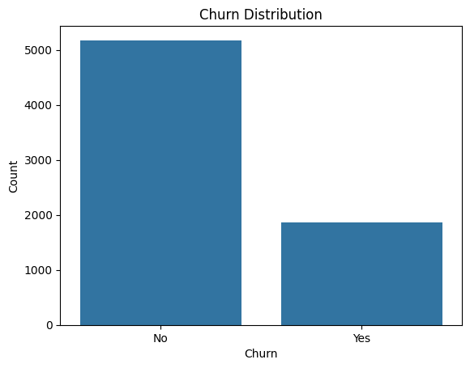

```
Churn Class Distribution:
Churn
No     5174
Yes    1869
Name: count, dtype: int64

Churn Rate:
Churn
No     73.46%
Yes    26.54%
Name: count, dtype: object

Churn Rate:
Churn
No     73.46%
Yes    26.54%
Name: count, dtype: object
```

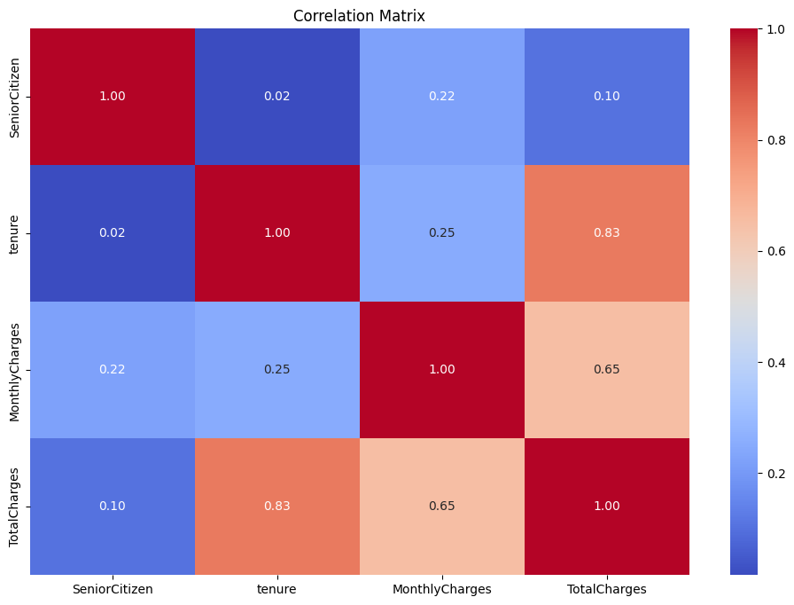

```python
# Load the dataset
df = pd.read_csv('Telco-Customer-Churn.csv')  # Replace with the actual path to your dataset
df.columns = df.columns.str.strip()  # Clean column names

# Display initial dataset structure
print("Initial Data Snapshot:")
print(df.head())

# Summary statistics of numerical features
print("\nSummary Statistics:")
print(df.describe())

# Check for missing values
print("\nMissing Values Count:")
print(df.isnull().sum())

# Data types of each column
print("\nData Types:")
print(df.dtypes)

# Churn distribution
sns.countplot(x='Churn', data=df)
plt.title('Churn Distribution')
plt.xlabel('Churn')
plt.ylabel('Count')
plt.show()

# Class imbalance
churn_counts = df['Churn'].value_counts()
print(f"\nChurn Class Distribution:\n{churn_counts}")


# Calculating the churn rate for each class
churn_rate = churn_counts / len(df) * 100
print("\nChurn Rate:")
print(churn_rate.apply(lambda x: f'{x:.2f}%'))

# Churn rate calculation
churn_rate = churn_counts / len(df) * 100
print("\nChurn Rate:")
print(churn_rate.apply(lambda x: f'{x:.2f}%'))

# Convert 'TotalCharges' to numeric
df['TotalCharges'] = pd.to_numeric(df['TotalCharges'], errors='coerce')

# Drop non-numeric columns and calculate correlation matrix
numeric_df = df.select_dtypes(include=[np.number])
plt.figure(figsize=(12, 8))
sns.heatmap(numeric_df.corr(), annot=True, cmap='coolwarm', fmt='.2f')
plt.title('Correlation Matrix')
plt.show()
```

**Data Preprocessing and Feature Engineering**

The data was prepared for machine learning techniques by converting categorical features into numerical values. Boolean features were also transformed to integers. This preprocessing guarantees that all data given into the model is properly formatted for analysis.

```python
# Preprocessing for ML models
from sklearn.preprocessing import LabelEncoder
le = LabelEncoder()

# Encode categorical variables
df['gender'] = le.fit_transform(df['gender'])
df['Churn'] = le.fit_transform(df['Churn'])

# Convert boolean columns to integers
bool_columns = ['Contract', 'PaymentMethod', 'PaperlessBilling']
df[bool_columns] = df[bool_columns].apply(lambda x: x.astype('category').cat.codes)

# Drop the 'customerID' column as it is not a feature useful for prediction
X = df.drop(['Churn', 'customerID'], axis=1)
y = df['Churn']

# Fill missing values
for column in X.columns:
    if X[column].dtype == 'object':  # If the column is categorical
        X[column].fillna(X[column].mode()[0], inplace=True)
    else:  # If the column is numerical
        X[column].fillna(X[column].median(), inplace=True)

# Re-encode categorical variables after filling missing values
for column in X.columns:
    if X[column].dtype == 'object':
        X[column] = le.fit_transform(X[column])
```

**Model Training**

Three models were trained to predict customer churn:

Random Forest:

Logistic Regression:

XGBoost:

```python
# Split dataset into training and testing sets
X_train, X_test, y_train, y_test = train_test_split(X, y, test_size=0.2, random_state=42)

# Model training with multiple algorithms
from sklearn.ensemble import RandomForestClassifier
from sklearn.linear_model import LogisticRegression
from xgboost import XGBClassifier

# Initialize models
models = {
    'Random Forest': RandomForestClassifier(),
    'Logistic Regression': LogisticRegression(max_iter=1000),
    'XGBoost': XGBClassifier(use_label_encoder=False, eval_metric='logloss')
}


# Train and evaluate models
for model_name, model in models.items():
    model.fit(X_train, y_train)
    y_pred = model.predict(X_test)

    # Evaluation metrics
    from sklearn.metrics import classification_report, roc_auc_score, roc_curve
    print(f"\n{model_name} - Classification Report:")
    print(classification_report(y_test, y_pred))
```

```
Random Forest - Classification Report:
              precision    recall  f1-score   support

           0       0.82      0.92      0.87      1036
           1       0.67      0.46      0.54       373

    accuracy                           0.80      1409
   macro avg       0.75      0.69      0.71      1409
weighted avg       0.78      0.80      0.78      1409


Logistic Regression - Classification Report:
              precision    recall  f1-score   support

           0       0.86      0.90      0.88      1036
           1       0.68      0.58      0.63       373

    accuracy                           0.82      1409
   macro avg       0.77      0.74      0.75      1409
weighted avg       0.81      0.82      0.81      1409


XGBoost - Classification Report:
              precision    recall  f1-score   support

           0       0.83      0.88      0.86      1036
           1       0.61      0.51      0.56       373

    accuracy                           0.78      1409
   macro avg       0.72      0.70      0.71      1409
weighted avg       0.77      0.78      0.78      1409
```

**Model Assessment**

**Model Evaluation**

The efficiency of the model was evaluated using a test set. Key metrics include:

[output not shown]

**Feature Importance**

The feature importance analysis determined which features have the greatest influence on customer churn. This knowledge can help the organization focus on important areas that impact client retention.

```
Random Forest - Classification Report:
              precision    recall  f1-score   support

           0       0.83      0.91      0.87      1036
           1       0.66      0.47      0.55       373

    accuracy                           0.80      1409
   macro avg       0.74      0.69      0.71      1409
weighted avg       0.78      0.80      0.78      1409

Random Forest - ROC-AUC Score: 0.83
```

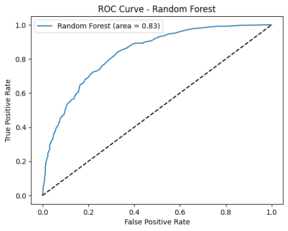

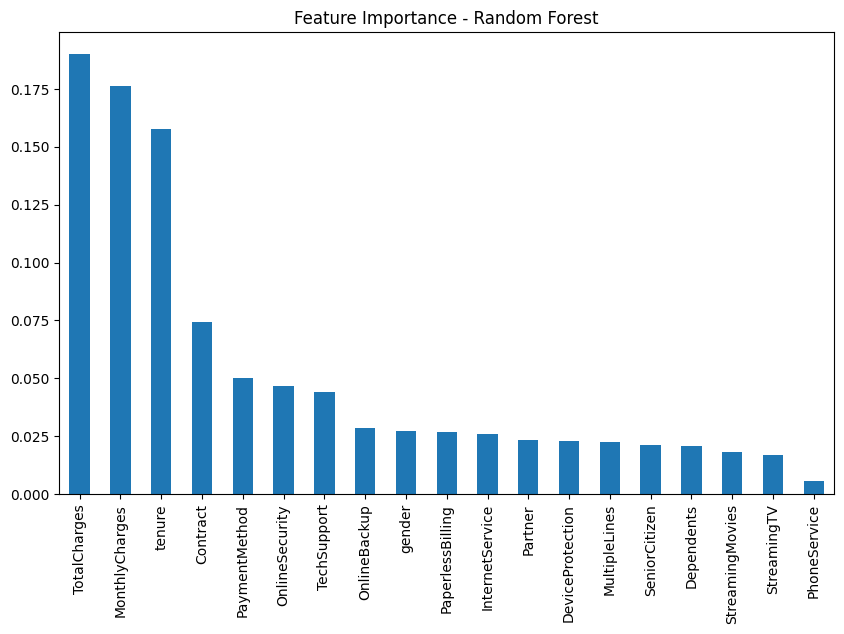

```
Logistic Regression - Classification Report:
              precision    recall  f1-score   support

           0       0.86      0.90      0.88      1036
           1       0.68      0.58      0.63       373

    accuracy                           0.82      1409
   macro avg       0.77      0.74      0.75      1409
weighted avg       0.81      0.82      0.81      1409

Logistic Regression - ROC-AUC Score: 0.86
```

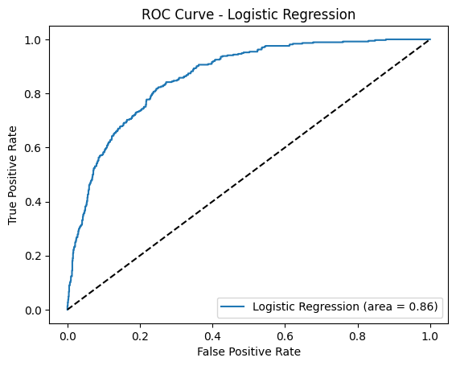

```
XGBoost - Classification Report:
              precision    recall  f1-score   support

           0       0.83      0.88      0.86      1036
           1       0.61      0.51      0.56       373

    accuracy                           0.78      1409
   macro avg       0.72      0.70      0.71      1409
weighted avg       0.77      0.78      0.78      1409

XGBoost - ROC-AUC Score: 0.83
```

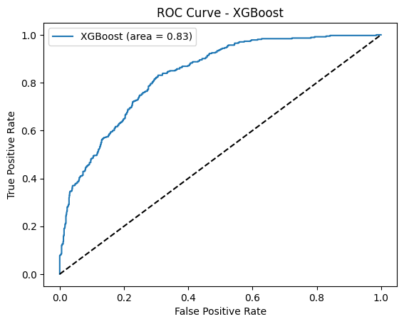

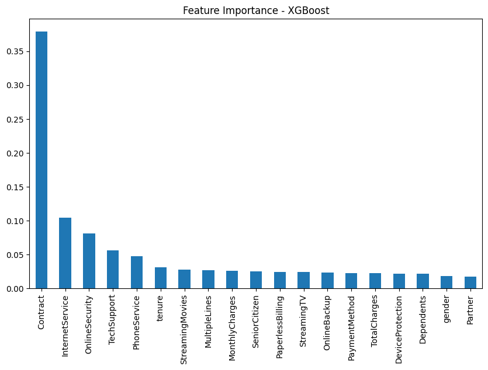

```python
# Preprocessing for ML models
from sklearn.preprocessing import LabelEncoder
le = LabelEncoder()

# Encode categorical variables
df['gender'] = le.fit_transform(df['gender'])
df['Churn'] = le.fit_transform(df['Churn'])

# Convert boolean columns to integers
bool_columns = ['Contract', 'PaymentMethod', 'PaperlessBilling']
df[bool_columns] = df[bool_columns].apply(lambda x: x.astype('category').cat.codes)

# Drop the 'customerID' column as it is not a feature useful for prediction
X = df.drop(['Churn', 'customerID'], axis=1)
y = df['Churn']

## Fill missing values
for column in X.columns:
    if X[column].dtype == 'object':  # If the column is categorical
        X[column].fillna(X[column].mode()[0], inplace=True)
    else:  # If the column is numerical
        X[column].fillna(X[column].median(), inplace=True)

# Re-encode categorical variables after filling missing values
for column in X.columns:
    if X[column].dtype == 'object':
        X[column] = le.fit_transform(X[column])

# Split dataset into training and testing sets
X_train, X_test, y_train, y_test = train_test_split(X, y, test_size=0.2, random_state=42)

# Model training with multiple algorithms
from sklearn.ensemble import RandomForestClassifier
from sklearn.linear_model import LogisticRegression
from xgboost import XGBClassifier

# Initialize models
models = {
    'Random Forest': RandomForestClassifier(),
    'Logistic Regression': LogisticRegression(max_iter=1000),
    'XGBoost': XGBClassifier(use_label_encoder=False, eval_metric='logloss')
}

# Train and evaluate models
for model_name, model in models.items():
    model.fit(X_train, y_train)
    y_pred = model.predict(X_test)

    # Evaluation metrics
    from sklearn.metrics import classification_report, roc_auc_score, roc_curve
    print(f"\n{model_name} - Classification Report:")
    print(classification_report(y_test, y_pred))

    # ROC-AUC score
    roc_auc = roc_auc_score(y_test, model.predict_proba(X_test)[:, 1])
    print(f"{model_name} - ROC-AUC Score: {roc_auc:.2f}")

    # ROC curve visualization
    fpr, tpr, _ = roc_curve(y_test, model.predict_proba(X_test)[:, 1])
    plt.figure()
    plt.plot(fpr, tpr, label=f'{model_name} (area = {roc_auc:.2f})')
    plt.plot([0, 1], [0, 1], 'k--')
    plt.title(f'ROC Curve - {model_name}')
    plt.xlabel('False Positive Rate')
    plt.ylabel('True Positive Rate')
    plt.legend(loc='best')
    plt.show()

    # Feature importance for tree-based models
    if hasattr(model, 'feature_importances_'):
        feature_importances = pd.Series(model.feature_importances_, index=X.columns).sort_values(ascending=False)
        plt.figure(figsize=(10, 6))
        feature_importances.plot(kind='bar')
        plt.title(f'Feature Importance - {model_name}')
        plt.show()
```

**Final Discussion**

Actionable Insights: The organization can use model insights to prevent churn, such as adjusting pricing strategies or improving customer service in areas where churn is high.

Future Enhancements: Explore alternative models (e.g., Gradient Boosting Machines or Neural Networks) and incorporating additional data sources to further improve model accuracy and interpretability.

**Strengths and Limitations**

**Strengths:**

Diverse Model Performance:

Different models showed varying strengths. Logistic Regression provided the best ROC-AUC score, suggesting high model accuracy in distinguishing churners from non-churners. Feature Insights: Feature importance analysis enabled a clear understanding of which factors are most likely to drive churn, allowing for targeted interventions. Limitations:

Class Imbalance:

The dataset's class imbalance may impact model performance, potentially biasing results toward the majority class. Model Generalizability: The models may perform differently when applied to new data or different customer demographics. Need for Further Refinement: Additional exploration of advanced algorithms, feature engineering, or resampling techniques could improve performance.

**Implications for the Business Problem**

The model's predictions can assist the organization in identifying at-risk clients and implementing focused retention tactics. By addressing the causes of churn, the organization can increase client satisfaction and loyalty.

**Data-Driven Recommendations**

Targeted Retention Strategies: Develop marketing campaigns focused on high-risk customer segments identified through model predictions.

Service Improvements: Focus on enhancing services or addressing pain points identified as key churn drivers (e.g., billing issues, service quality).

Ongoing Monitoring and Model Updating: Continuously update the model with new data to maintain accuracy and relevance.

**Model Explainability**

The Random Forest model's feature importance provides transparency into the factors influencing churn, aiding decision-makers in understanding and trusting the model's predictions. Further measures, such as SHAP values, could improve interpretability and trust.

**Link to Github**

https://github.com/MuhammadAhmadJamil18/B104_Artificial-Intelligence-Machine-Learning